# Part I - Loan Data Exploration

## Introduction

This document explores a dataset containing loans (extracted from [Prosper](https://www.prosper.com/), America's first peer-to-peer lending marketplace, with over $7 billion in funded loans) with 81 variables on each loan, including loan amount, borrower rate (or interest rate), current loan status, borrower income and many others.

## Preliminary Wrangling

```python
import numpy as np
import pandas as pd
import seaborn as sb
import matplotlib.pyplot as plt

%matplotlib inline
```

```python
sb.set()
```

```python
loans = pd.read_csv('prosper-loan.csv')
```

```python
loans.head()
```

|  | ListingKey | ListingNumber | ListingCreationDate | CreditGrade | Term | LoanStatus | ClosedDate | BorrowerAPR | BorrowerRate | LenderYield | ... | LP_ServiceFees | LP_CollectionFees | LP_GrossPrincipalLoss | LP_NetPrincipalLoss | LP_NonPrincipalRecoverypayments | PercentFunded | Recommendations | InvestmentFromFriendsCount | InvestmentFromFriendsAmount | Investors |
| --- | --- | --- | --- | --- | --- | --- | --- | --- | --- | --- | --- | --- | --- | --- | --- | --- | --- | --- | --- | --- | --- |
| 0 | 1021339766868145413AB3B | 193129 | 2007-08-26 19:09:29.263000000 | C | 36 | Completed | 2009-08-14 00:00:00 | 0.16516 | 0.1580 | 0.1380 | ... | -133.18 | 0.0 | 0.0 | 0.0 | 0.0 | 1.0 | 0 | 0 | 0.0 | 258 |
| 1 | 10273602499503308B223C1 | 1209647 | 2014-02-27 08:28:07.900000000 | NaN | 36 | Current | NaN | 0.12016 | 0.0920 | 0.0820 | ... | 0.00 | 0.0 | 0.0 | 0.0 | 0.0 | 1.0 | 0 | 0 | 0.0 | 1 |
| 2 | 0EE9337825851032864889A | 81716 | 2007-01-05 15:00:47.090000000 | HR | 36 | Completed | 2009-12-17 00:00:00 | 0.28269 | 0.2750 | 0.2400 | ... | -24.20 | 0.0 | 0.0 | 0.0 | 0.0 | 1.0 | 0 | 0 | 0.0 | 41 |
| 3 | 0EF5356002482715299901A | 658116 | 2012-10-22 11:02:35.010000000 | NaN | 36 | Current | NaN | 0.12528 | 0.0974 | 0.0874 | ... | -108.01 | 0.0 | 0.0 | 0.0 | 0.0 | 1.0 | 0 | 0 | 0.0 | 158 |
| 4 | 0F023589499656230C5E3E2 | 909464 | 2013-09-14 18:38:39.097000000 | NaN | 36 | Current | NaN | 0.24614 | 0.2085 | 0.1985 | ... | -60.27 | 0.0 | 0.0 | 0.0 | 0.0 | 1.0 | 0 | 0 | 0.0 | 20 |

5 rows × 81 columns

```python
df = loans[[
    'ListingKey',
    'LoanOriginalAmount',
    'Term',
    'BorrowerAPR',
    'BorrowerRate',
    'ProsperRating (Alpha)',
    'EstimatedReturn',
    'MonthlyLoanPayment',
    'EmploymentStatus',
    'IncomeRange',
    'StatedMonthlyIncome',
    'LoanStatus',
    'ListingCategory (numeric)'
]].copy()
```

```python
# rename some columns
df.rename(
    columns = {
        'ProsperRating (Alpha)': 'ProsperRating',
        'ListingCategory (numeric)': 'ListingCategory'
    },
    inplace = True
)
```

```python
df.head()
```

|  | ListingKey | LoanOriginalAmount | Term | BorrowerAPR | BorrowerRate | ProsperRating | EstimatedReturn | MonthlyLoanPayment | EmploymentStatus | IncomeRange | StatedMonthlyIncome | LoanStatus | ListingCategory |
| --- | --- | --- | --- | --- | --- | --- | --- | --- | --- | --- | --- | --- | --- |
| 0 | 1021339766868145413AB3B | 9425 | 36 | 0.16516 | 0.1580 | NaN | NaN | 330.43 | Self-employed | $25,000-49,999 | 3083.333333 | Completed | 0 |
| 1 | 10273602499503308B223C1 | 10000 | 36 | 0.12016 | 0.0920 | A | 0.05470 | 318.93 | Employed | $50,000-74,999 | 6125.000000 | Current | 2 |
| 2 | 0EE9337825851032864889A | 3001 | 36 | 0.28269 | 0.2750 | NaN | NaN | 123.32 | Not available | Not displayed | 2083.333333 | Completed | 0 |
| 3 | 0EF5356002482715299901A | 10000 | 36 | 0.12528 | 0.0974 | A | 0.06000 | 321.45 | Employed | $25,000-49,999 | 2875.000000 | Current | 16 |
| 4 | 0F023589499656230C5E3E2 | 15000 | 36 | 0.24614 | 0.2085 | D | 0.09066 | 563.97 | Employed | $100,000+ | 9583.333333 | Current | 2 |

```python
# high-level overview of data shape and composition
print(df.shape)
print(df.dtypes)
```

```
(113937, 13)
ListingKey              object
LoanOriginalAmount       int64
Term                     int64
BorrowerAPR            float64
BorrowerRate           float64
ProsperRating           object
EstimatedReturn        float64
MonthlyLoanPayment     float64
EmploymentStatus        object
IncomeRange             object
StatedMonthlyIncome    float64
LoanStatus              object
ListingCategory          int64
dtype: object
```

```python
print(df.LoanStatus.value_counts())
print(df.ProsperRating.value_counts())
print(df.EmploymentStatus.value_counts())
print(df.Term.value_counts())
print(df.ListingCategory.value_counts())
```

```
Current                   56576
Completed                 38074
Chargedoff                11992
Defaulted                  5018
Past Due (1-15 days)        806
Past Due (31-60 days)       363
Past Due (61-90 days)       313
Past Due (91-120 days)      304
Past Due (16-30 days)       265
FinalPaymentInProgress      205
Past Due (>120 days)         16
Cancelled                     5
Name: LoanStatus, dtype: int64
C     18345
B     15581
A     14551
D     14274
E      9795
HR     6935
AA     5372
Name: ProsperRating, dtype: int64
Employed         67322
Full-time        26355
Self-employed     6134
Not available     5347
Other             3806
Part-time         1088
Not employed       835
Retired            795
Name: EmploymentStatus, dtype: int64
36    87778
60    24545
12     1614
Name: Term, dtype: int64
1     58308
0     16965
7     10494
2      7433
3      7189
6      2572
4      2395
13     1996
15     1522
18      885
14      876
20      771
19      768
5       756
16      304
11      217
8       199
10       91
9        85
12       59
17       52
Name: ListingCategory, dtype: int64
```

```python
# Convert some values into ordered categorical types.
# 'Term' is a discrete quantitative variable (in this case with only three possible values)
# so I will convert it into a categorical variable.
ordinal_var_dict = {
    'LoanStatus': [
        'Current',
        'Completed',
        'Chargedoff',
        'Defaulted',
        'Past Due (1-15 days)',
        'Past Due (31-60 days)',
        'Past Due (61-90 days)',
        'Past Due (91-120 days)',
        'Past Due (16-30 days)',
        'FinalPaymentInProgress',
        'Past Due (>120 days)',
        'Cancelled'
    ],
    'Term': [
        36,
        60,
        12
    ],
    'EmploymentStatus': [
        'Employed',
        'Full-time',
        'Self-employed',
        'Not available',
        'Other',
        'Part-time',
        'Not employed',
        'Retired'
    ],
    'ProsperRating': ['AA', 'A', 'B', 'C', 'D', 'E', 'HR']
}

for var in ordinal_var_dict:
    ordered_var = pd.api.types.CategoricalDtype(
        ordered = True,
        categories = ordinal_var_dict[var]
    )
    df[var] = df[var].astype(ordered_var)
```

```python
# check duplicated loans
df.duplicated(subset=['ListingKey']).sum()
```

```
871
```

```python
# remove duplicated loans
df.drop_duplicates(subset=['ListingKey'], inplace = True)
print(df.duplicated(subset=['ListingKey']).sum())
```

```
0
```

```python
df.isna().sum()
```

```
ListingKey                 0
LoanOriginalAmount         0
Term                       0
BorrowerAPR               25
BorrowerRate               0
ProsperRating          29084
EstimatedReturn        29084
MonthlyLoanPayment         0
EmploymentStatus        2255
IncomeRange                0
StatedMonthlyIncome        0
LoanStatus                 0
ListingCategory            0
dtype: int64
```

```python
# remove numeric values with missing information (loans prior to July 2009)
df.dropna(
    axis = 0,
    subset = [
        'BorrowerAPR',
        'ProsperRating',
        'EstimatedReturn'
    ],
    inplace = True
)
```

```python
# round StatedMonthlyIncome values to two decimal places
df.StatedMonthlyIncome = df.StatedMonthlyIncome.round(2)
```

```python
df.info()
```

```
<class 'pandas.core.frame.DataFrame'>
Int64Index: 83982 entries, 1 to 113936
Data columns (total 13 columns):
ListingKey             83982 non-null object
LoanOriginalAmount     83982 non-null int64
Term                   83982 non-null category
BorrowerAPR            83982 non-null float64
BorrowerRate           83982 non-null float64
ProsperRating          83982 non-null category
EstimatedReturn        83982 non-null float64
MonthlyLoanPayment     83982 non-null float64
EmploymentStatus       83982 non-null category
IncomeRange            83982 non-null object
StatedMonthlyIncome    83982 non-null float64
LoanStatus             83982 non-null category
ListingCategory        83982 non-null int64
dtypes: category(4), float64(5), int64(2), object(2)
memory usage: 6.7+ MB
```

```python
# descriptive statistics for numeric variables
print(df.describe())
```

```
       LoanOriginalAmount   BorrowerAPR  BorrowerRate  EstimatedReturn  \
count        83982.000000  83982.000000   83982.00000     83982.000000
mean          9061.224381      0.226945       0.19630         0.096246
std           6279.649648      0.080047       0.07475         0.030475
min           1000.000000      0.045830       0.04000        -0.182700
25%           4000.000000      0.163610       0.13590         0.074630
50%           7500.000000      0.219450       0.18750         0.092110
75%          13500.000000      0.292540       0.25740         0.117100
max          35000.000000      0.423950       0.36000         0.283700

       MonthlyLoanPayment  StatedMonthlyIncome  ListingCategory
count         83982.00000         8.398200e+04     83982.000000
mean            291.40139         5.930614e+03         3.321771
std             186.47539         8.268432e+03         4.368851
min               0.00000         0.000000e+00         0.000000
25%             157.11250         3.426940e+03         1.000000
50%             251.28000         5.000000e+03         1.000000
75%             387.62000         7.083330e+03         3.000000
max            2251.51000         1.750003e+06        20.000000
```

### What is the structure of your dataset?

The original dataset consists of 113,937 loan records with 81 features. This [data dictionary](https://docs.google.com/spreadsheets/d/1gDyi_L4UvIrLTEC6Wri5nbaMmkGmLQBk-Yx3z0XDEtI/edit#gid=0) explains variables.

For this project, a second data set has been formed based on the original with 13 features on which the Exploration Data Analisys (EDA) will focus.

[output not shown]

### What is/are the main feature(s) of interest in your dataset?

Firstly, I am interested in identifying what affects the borrower's APR or interest rate, one of the most important parameters when applying for a loan. Then, what are the differences between loans depending on how large the original loan amount is. Finally, what factors affect a loan’s status.

### What features in the dataset do you think will help support your investigation into your feature(s) of interest?

I have created a dataset with some features that I think will be helpful in the research: the borrower's interest rate (BorrowerRate) and the assigned Prosper rating (ProsperRating - Alpha) will affect the Borrower's Annual Percentage Rate (BorrowerAPR) for the loan, as these parameters are used to calculate this last value, and will also set the estimated return (EstimatedReturn). The original loan amount (LoanOriginalAmount) is likely to vary depending on its use (ListingCategory) and the current status (LoanStatus) could depend on the length, in months, (Term) and the monthly payment (MonthlyLoanPayment), which in turn will depend on the borrower's employment status when applying for the loan (EmploymentStatus) and the borrower's income range, annually (IncomeRange) and monthly (StatedMonthlyIncome). All these data can help to draw conclusions about the main features of interest in the dataset.

## Univariate Exploration

I will start by taking a look at the distribution of one of the main variables of interest: Borrower's APR

Following the definitions from [Bank of America](https://www.bankofamerica.com/mortgage/learn/apr-vs-interest-rate/):

- APR (BorrowerAPR) is the annual cost of a loan to a borrower — including fees. Unlike an interest rate, however, it includes other charges or fees such as mortgage insurance, most closing costs, discount points and loan origination fees.
- Interest rate (BorrowerRate) refers to the annual cost of a loan to a borrower.

This means that the distribution of BorrowerAPR and BorrowerRate should be similar with slight difference since the APR is always higher than the interest rate.

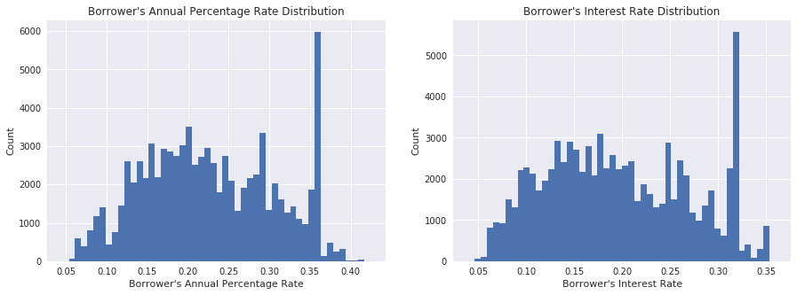

```python
plt.figure(figsize = [15, 5])

plt.subplot(1, 2, 1)
sb.distplot(
    df.BorrowerAPR,
    kde = False,
    hist_kws = {'alpha' : 1}
)
plt.title("Borrower's Annual Percentage Rate Distribution")
plt.ylabel('Count')
plt.xlabel("Borrower's Annual Percentage Rate")

plt.subplot(1, 2, 2)
sb.distplot(
    df.BorrowerRate,
    kde = False,
    hist_kws = {'alpha' : 1}
)
plt.title("Borrower's Interest Rate Distribution")
plt.ylabel('Count')
plt.xlabel("Borrower's Interest Rate");
```

There are two peaks centered at 0.2 and 0.28, respectively, and a very shaped peak between 0.35 and 0.36. A very small number of loans have an APR higher than 0.4.

Indeed, the interest rate retains the same multi-modal distribution with slightly lower values.

Let's put both variables on the same plot to better appreciate the similar distribution

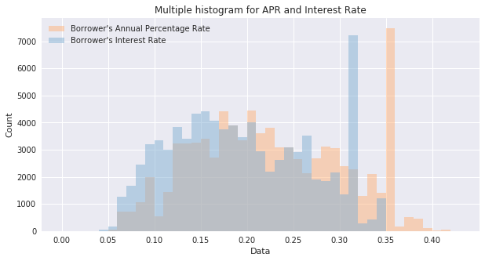

```python
binsize = 0.01
bins = np.arange(0, df.BorrowerAPR.max() + binsize, binsize)

plt.figure(figsize=(10,5))

plt.hist(
    df.BorrowerAPR,
    bins = bins,
    color = "#ffb47b",
    alpha = 0.5,
    label = "Borrower's Annual Percentage Rate",
)
plt.hist(
    df.BorrowerRate,
    bins = bins,
    color = "#84b1d4",
    alpha = 0.5,
    label = "Borrower's Interest Rate",
)
plt.legend()
plt.title("Multiple histogram for APR and Interest Rate")
plt.ylabel('Count')
plt.xticks([0, 0.05, 0.1, 0.15, 0.20, 0.25, 0.30, 0.35, 0.40])
plt.xlabel("Data");
```

Next, I would like to look at another of the main variables of interest for prediction: the original loans amounts

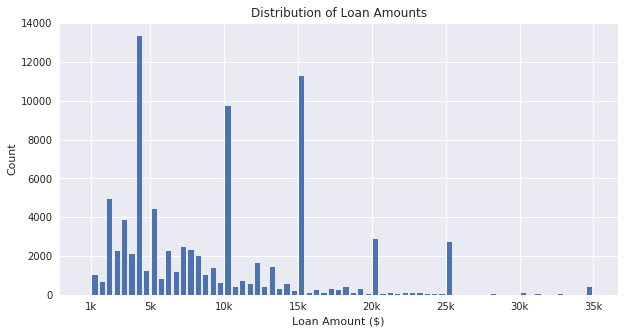

```python
binsize = 500
bins = np.arange(500, df.LoanOriginalAmount.max() + binsize, binsize)

plt.figure(figsize = (10, 5))
plt.hist(
    data = df,
    x = 'LoanOriginalAmount',
    bins = bins,
    rwidth = 0.7
)
plt.title("Distribution of Loan Amounts")
plt.ylabel('Count')
plt.xlabel('Loan Amount ($)')
plt.xticks(
    [1e3, 5e3, 10e3, 15e3, 20e3, 25e3, 30e3, 35e3],
    ['1k', '5k', '10k', '15k', '20k', '25k', '30k', '35k']
);
```

The majority of loans are in amounts of around \$4,000, \\$10,000, \$15,000, \\$20,000 and \$25,000 with a very small number of loans between \\$30,000 and \$35,000.

To finish looking at the main variables of interest, let's observe the loans status by percentage.

```python
# number of days the payment is due is not a variable of interest for the investigation so I will
# combine all these categorical variables into one.
df['LoanStatus'].replace(
    [
        'Past Due (1-15 days)',
        'Past Due (31-60 days)',
        'Past Due (61-90 days)',
        'Past Due (91-120 days)',
        'Past Due (16-30 days)',
        'Past Due (>120 days)'
    ],
    'Past Due',
    inplace = True
)
```

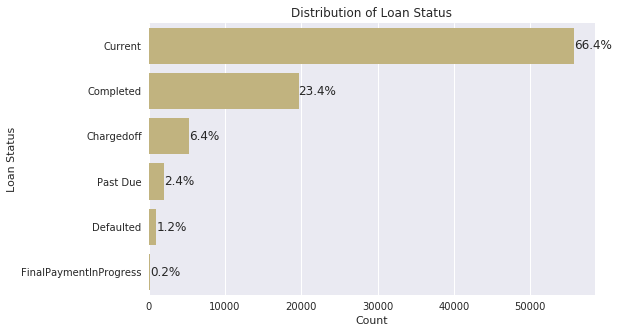

```python
# get series containing counts of unique values in descending order (first element the most frequently-occurring)
loan_status_counts = df.LoanStatus.value_counts()

# get the unique values in the decreasing order of the frequency
loan_status_order = loan_status_counts.index

# return the sum of all not-null values
n_loan = loan_status_counts.sum()

plt.figure(figsize = (8,5))

sb.countplot(
    data = df,
    y = 'LoanStatus',
    order = loan_status_order,
    color = sb.color_palette()[4]
)
plt.title('Distribution of Loan Status')
plt.ylabel('Loan Status')
plt.xlabel('Count')

for i in range (loan_status_counts.shape[0]):
    count = loan_status_counts[i]
    # convert count into a percentage, and then into string
    pct_string = '{:0.1f}'.format(100 * count / n_loan) + '%'
    # print the string value on the bar
    plt.text(count + 1, i, pct_string, va = 'center')
```

There are 66.4% of loans that are still being repaid and 23.4% of loans that have already been completed. These two status represent 89.8% of the loans in the dataset, making the remaining an insignificant percentage to be studied.

I'll now look at the other features in the data to see if any of them hold interesting properties.

What about loan ratings? Prosper ratings allow potential investors to easily consider a loan application's level of risk because the rating represents an estimated average annualized loss rate range to the investor. This rating is a system patented by the company to maintain consistency in the evaluation of the loan.

Following this [link](https://www.prosper.com/invest/how-to-invest/prosper-ratings/?mod=article_inline) explains the percentages for the Annual Loss Rate. Two scores are used to calculate this value: the borrower's credit score (CreditGrade), obtained from an official credit reporting agency, and the Prosper score (ProsperScore), figured in-house based on the Prosper population.

Therefore, in order to obtain meaningful conclusions, only the resulting final value that is useful to the investor is observed, that is, 'ProsperRating' column.

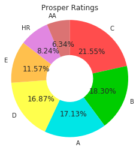

```python
prosper_rating_counts = df.ProsperRating.value_counts()

plt.pie(
    prosper_rating_counts,
    labels = prosper_rating_counts.index,
    startangle = 90,
    counterclock = False,
    wedgeprops = {'width' : 0.6},
    colors = ['#ff4d4d', '#00cd00','#00e6e6','#ffff4d','#ffc04d', '#e187e1', '#db7373'],
    autopct = '%1.2f%%'
);

plt.axis('square')
plt.title('Prosper Ratings');
```

Most loans are rated between A and D, which corresponds to an annual loss rate of 2.00-3.99% and 9.00-11.99%, respectively.

Next, the estimated return assigned.

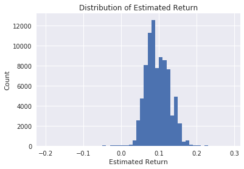

```python
binsize = 0.01
bins = np.arange(-0.2, df.EstimatedReturn.max() + binsize, binsize)

plt.hist(
    data = df,
    x = 'EstimatedReturn',
    bins = bins
)
plt.title('Distribution of Estimated Return')
plt.ylabel('Count')
plt.xlabel('Estimated Return');
```

The distribution is unimodal and slightly skewed with a peak centered at 0.08

Now, I will have a look at the borrower's employment status.

```python
# some of these categorical variables can be combined into a single one.
df['EmploymentStatus'].replace(
    {
        'Full-time': 'Employed',
        'Self-employed': 'Employed',
        'Part-time': 'Employed',
        'Not available': 'Other'
    },
    inplace = True
)
```

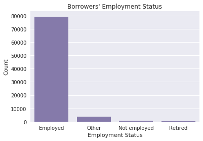

```python
sb.countplot(
    data = df,
    x = 'EmploymentStatus',
    order = df.EmploymentStatus.value_counts().index,
    color = sb.color_palette()[3]
)
plt.title("Borrowers' Employment Status")
plt.ylabel('Count')
plt.xlabel('Employment Status');
```

Nearly all borrowers are employed at the time they apply for a loan, with a very limited number of those who apply being unemployed or retired. These other options represent an insignificant percentage of the total. Therefore, this variable does not affect our variables of interest and will not be further investigated in the following sections.

Next, I will take a look at two other variables of interest related to the borrower's employment, the annual income range and the stated monthly income.

```python
# some of these values can be combined into a single value.
df['IncomeRange'].replace(
    ['Not employed'],
    '$0',
    inplace = True
)
```

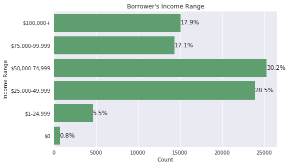

```python
# get series containing counts of unique values in descending order (first element the most frequently-occurring)
income_range_counts = df.IncomeRange.value_counts()

# get the unique values in the decreasing order of the frequency
income_rang_order = income_range_counts.index

# returns the sum of all not-null values
n_income_range = income_range_counts.sum()

order = [
    '$100,000+',
    '$75,000-99,999',
    '$50,000-74,999',
    '$25,000-49,999',
    '$1-24,999',
    '$0'
]

# set figure size
plt.figure(figsize = (8,5))

sb.countplot(
    data = df,
    y = 'IncomeRange',
    order = order,
    color = sb.color_palette()[1]
)
plt.title("Borrower's Income Range")
plt.ylabel('Income Range')
plt.xlabel('Count')

for i in range (len(order)):
    value = order[i]
    count = income_range_counts[value]
    # convert count into a percentage, and then into string
    pct_string = '{:0.1f}'.format(100 * count / n_income_range) + '%'
    # print the string value on the bar.
    plt.text(count + 1, i, pct_string, va = 'center')
```

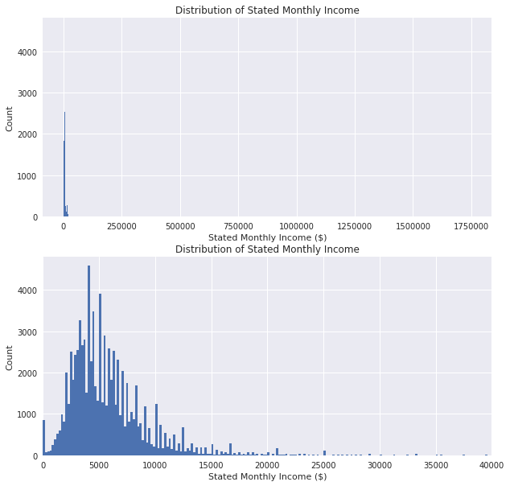

```python
plt.figure(figsize = [10, 10])

binsize = 200
bins = np.arange(0, df.StatedMonthlyIncome.max() + binsize, binsize)

plt.subplot(2, 1, 1)
plt.hist(
    data = df,
    x = 'StatedMonthlyIncome',
    bins = bins
)
plt.title('Distribution of Stated Monthly Income')
plt.ylabel('Count')
plt.xlabel('Stated Monthly Income ($)')

plt.subplot(2, 1, 2)
plt.hist(
    data = df,
    x = 'StatedMonthlyIncome',
    bins = bins
)
# change the axis limits to make the observations
plt.xlim(0, 40000)
plt.title('Distribution of Stated Monthly Income')
plt.ylabel('Count')
plt.xlabel('Stated Monthly Income ($)');
```

The first histogram clearly shows an area for further investigation and clarification. The plot covers an unexpected range, indicating that there are some strong outliers on the right that cause all of the other points to be fit into the first bar.

In the second plot, I change the range of the data plotted in order to zoom into the part that is more interesting. This new histogram shows an unimodal right-skewed distribution of the data.

The majority of borrowers are in the range of monthly incomes from approximately \$2,000 to \\$8,000 per month.

It's worth taking a bit of time to identify these outliers.

```python
# select high outliers, using criteria eyeballed from the plots
upper_limit = 40000

high_outliers = df[df.StatedMonthlyIncome > upper_limit]

print(high_outliers.shape)
```

```
(108, 13)
```

```python
# get percent of borrowers whose stated monthly income greater than 40k
(df.StatedMonthlyIncome > upper_limit).sum() / float(df.shape[0]) * 100
```

```
0.12859898549689219
```

There are only 108 outliers for stated monthly income, which is less than 0.3% of borrowers. These can be seemed as outlier for the following analysis so I will remove all of these inconsistent data points.

```python
# remove points with inconsistent values
df.drop(df[df.StatedMonthlyIncome > upper_limit].index, inplace = True)

print(df[df.StatedMonthlyIncome > upper_limit].shape)
```

```
(0, 13)
```

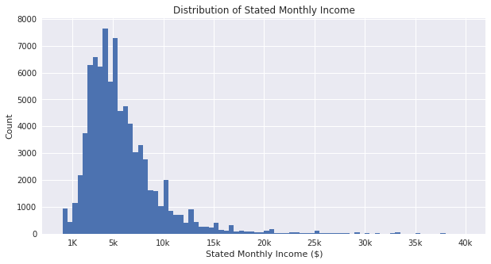

```python
# re-plot the stated monthly income distribution
plt.figure(figsize = [10, 5])

binsize = 500
bins = np.arange(0, df.StatedMonthlyIncome.max() + binsize, binsize)

plt.hist(
    data = df,
    x = 'StatedMonthlyIncome',
    bins = bins
)
plt.title('Distribution of Stated Monthly Income')
plt.ylabel('Count')
plt.xlabel('Stated Monthly Income ($)')
plt.xticks(
    [1e3, 5e3, 10e3, 15e3, 20e3, 25e3, 30e3, 35e3, 40e3],
    ['1K', '5k', '10k', '15k', '20k', '25k', '30k', '35k', '40k']
);
```

I will now move to other variables in the dataset: 'Term' and 'MonthlyLoanPayment'

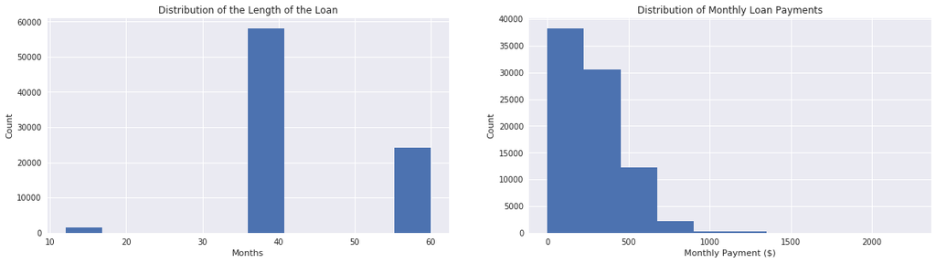

```python
plt.figure(figsize = [20, 5])

plt.subplot(1, 2, 1)
plt.hist(
    data = df,
    x = 'Term'
)
plt.title("Distribution of the Length of the Loan")
plt.ylabel('Count')
plt.xlabel('Months')

plt.subplot(1, 2, 2)
plt.hist(
    data = df,
    x = 'MonthlyLoanPayment'
)
plt.title('Distribution of Monthly Loan Payments')
plt.ylabel('Count')
plt.xlabel('Monthly Payment ($)');
```

The distribution of the first histogram indicates that loans can be spread over 12, 36 or 60 months. These probably represent standard values for use in loans, with 36-month loan lengths being more common.

The second histogram, monthly loan payments show an unimodal right-skewed distribution. I will change the axis limits to see the shape of where most of the data points are located, up to a maximum limit of \$1500.

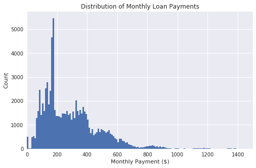

```python
binsize = 10
bins = np.arange(0, df.MonthlyLoanPayment.max() + binsize, binsize)

plt.figure(figsize = (8,5))
plt.hist(
    data = df,
    x = 'MonthlyLoanPayment',
    bins = bins
)
plt.xlim(0, 1500)
plt.title('Distribution of Monthly Loan Payments')
plt.ylabel('Count')
plt.xlabel('Monthly Payment ($)');
```

Here it can be seen in more detail that monthly payments are concentrated in a range from \$50 to approximately \\$400, with a peak around \$200, which corresponds to the most frequent monthly payment.

Before closing this section, I'll take a look at the last variable: the category of the listing that the borrower selected.

```python
# category listing:
category_dict = {
    0: 'Not Available',
    1: 'Debt Consolidation',
    2: 'Home Improvement',
    3: 'Business',
    4: 'Personal Loan',
    5: 'Student Use',
    6: 'Auto',
    7: 'Other',
    8: 'Baby&Adoption',
    9: 'Boat',
    10: 'Cosmetic Procedure',
    11: 'Engagement Ring',
    12: 'Green Loans',
    13: 'Household Expenses',
    14: 'Large Purchases',
    15: 'Medical/Dental',
    16: 'Motorcycle',
    17: 'RV',
    18: 'Taxes',
    19: 'Vacation',
    20: 'Wedding Loans'
}
```

```python
# replace the numerical values by the corresponding category
df['ListingCategory'].replace(
    category_dict.keys(),
    category_dict.values(),
    inplace = True
)
```

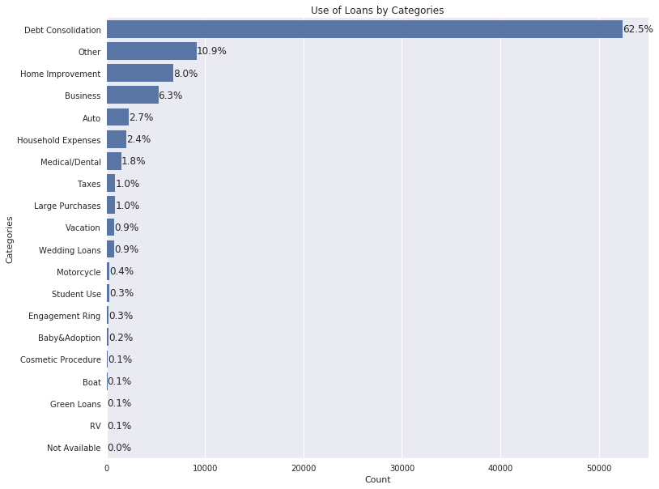

```python
# get series containing counts of unique values in descending order (first element the most frequently-occurring)
listing_category_counts = df.ListingCategory.value_counts()

# get the unique values in the decreasing order of the frequency
listing_category_order = listing_category_counts.index

# returns the sum of all not-null values
n_listing_category = listing_category_counts.sum()

plt.figure(figsize = (12, 10))

sb.countplot(
    data = df,
    y = 'ListingCategory',
    order = listing_category_order,
    color = sb.color_palette()[0]
)
plt.title('Use of Loans by Categories')
plt.ylabel('Categories')
plt.xlabel('Count');

for i in range (listing_category_counts.shape[0]):
    count = listing_category_counts[i]
    # convert count into a percentage, and then into string
    pct_string = '{:0.1f}'.format(100 * count / n_listing_category) + '%'
    # print the string value on the bar
    plt.text(count + 1, i, pct_string, va = 'center')
```

By a large margin, more than 50.000 (62.5%) of the loans granted are for the purpose of debt consolidation. Debt consolidation is a form of debt refinancing that involves taking out one loan to pay off many others. Although the original dataset offers the option to investigate whether borrowers have other loans granted with the same company (TotalProsperLoans), this variable is not considered to be of interest as users may have other types of debts. Other notable uses are 'Home Improvement', 'Business' and 'Auto'. Category "Other" could indicate that there are many other types of use that have not been recorded and have been classified in this group.

In any case, these data indicate that this variable is not significant to set differences according to the amount of the loan.

### Discuss the distribution(s) of your variable(s) of interest. Were there any unusual points? Did you need to perform any transformations?

The distribution of the Borrower's Annual Percentage Rate (APR) for the loan looks multimodal. For the loan orignal amount there are several peaks centered at \$4,000, \\$10,000, \$15,000, \\$20,000 and \$25,000.

Unusual points were found and eliminated in the stated monthly income variable. No need to perform any transformations on these three variables.

### Of the features you investigated, were there any unusual distributions? Did you perform any operations on the data to tidy, adjust, or change the form of the data? If so, why did you do this?

Duplicate loan records and numeric values with missing information have been removed.

Some column values have been converted to categorical types.

For the 'LoanStatus' column, the 'Pas Due' type categories have been merged into one, since it is not a value of interest for the investigation. The same goes for some categories in the "IncomeRange" and "EmploymentStatus" columns.

When investigating stated monthly income, a number of outlier points were identified. Overall, these points could be characterized by an inconsistency between the recorded value and the other features. For security, all of these points were removed from the dataset in order to move forward.

## Bivariate Exploration

To start off with, I want to look at the pairwise correlations present between **numerical features** in the data.

```python
numerical_vars = [
    'LoanOriginalAmount',
    'BorrowerAPR',
    'BorrowerRate',
    'EstimatedReturn',
    'MonthlyLoanPayment',
    'StatedMonthlyIncome'
]
```

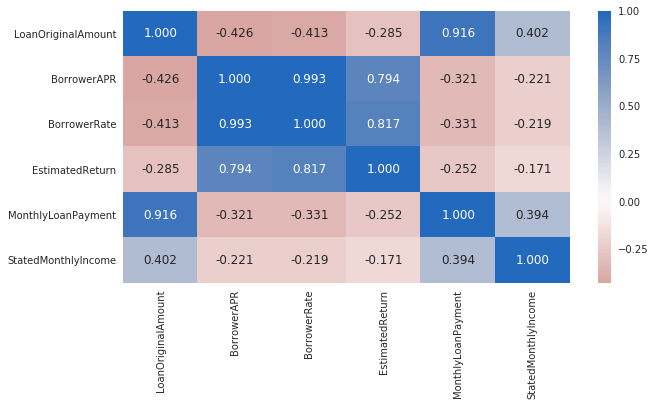

```python
# correlation plot
plt.figure(figsize = [10, 5])

sb.heatmap(
    df[numerical_vars].corr(),
    annot = True,
    fmt = '.3f',
    cmap = 'vlag_r',
    center = 0
);
```

```
loans_samp.shape= (1000, 13)
```

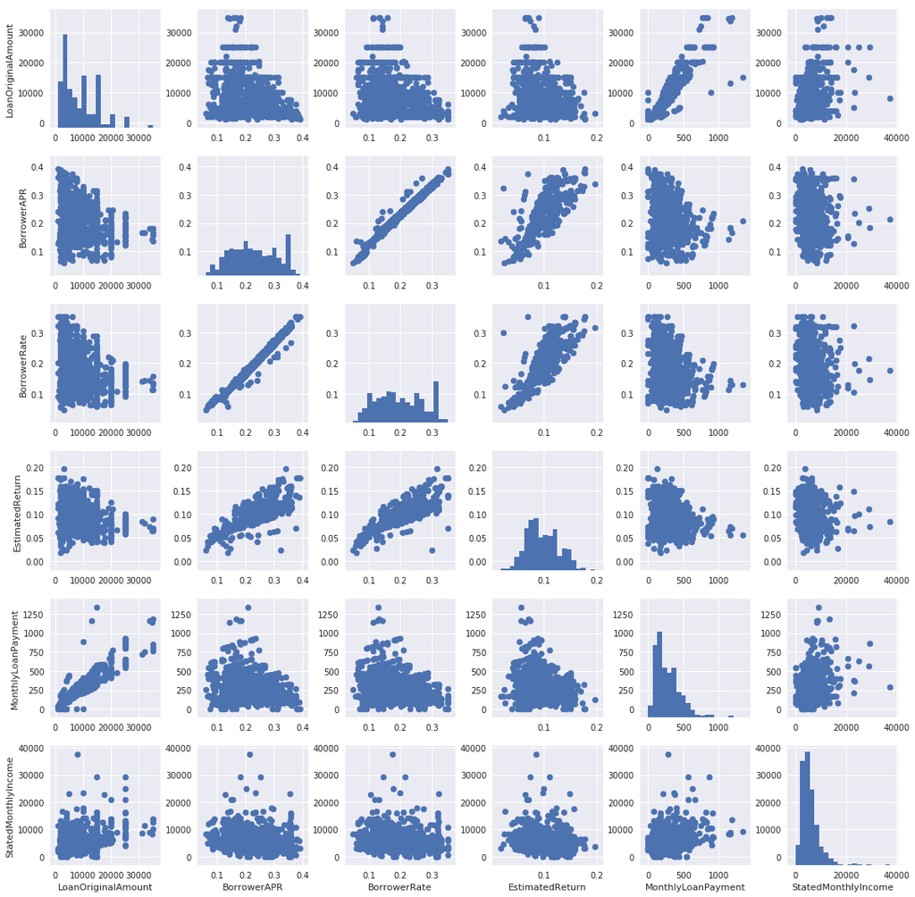

```python
# plot matrix: sample 1000 loans so that plots are clearer and they render faster
loans_sample = df.sample(n  = 1000, replace = False)
print("loans_samp.shape=", loans_sample.shape)

g = sb.PairGrid(
    data = loans_sample,
    vars = numerical_vars
)
g = g.map_diag(
    plt.hist,
    bins = 20
)
g.map_offdiag(plt.scatter);
```

The original loan amount, one of the main variables of interest, shows a strong positive correlation with the monthly payment variable, which makes sense, if the loan amount is higher so is the monthly amount. How does the length of the loan (in months) affect both variables? It could also be the case that this monthly payment amount has a linear relationship with the income range. These options will be explored below. Finally, there is a negative correlation with both the annual percentage rate and the interest rate, which is also to be expected.

On the other hand, as mentioned at the beginning, the annual percentage rate (BorrowerAPR) has a similar distribution to the annual interest rate (BorrowerRate), so it is not surprising that the two are strongly correlated with each other. This APR also has a high correlation with the estimated return on the loan, which also makes sense.

Below are the most interesting plots using the full data.

```python
def plot_numerical_vars(x, numerical_vars):
    for i in range(len(numerical_vars)):
        var = numerical_vars[i]
        plt.sca(axes[i])
        sb.regplot(
            data = df,
            y = var,
            x = x,
            truncate = False,
            scatter_kws = {'alpha':1/10}
)
```

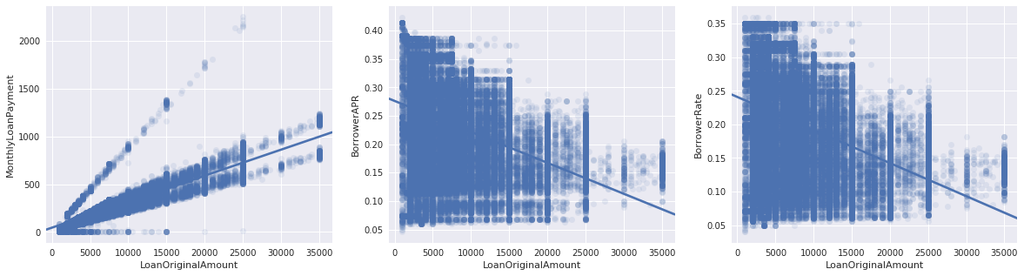

```python
# plot some numerical variables against the original loan amount, this time with full data.
fig, axes = plt.subplots(
    nrows = 1,
    ncols = 3,
    figsize = [20,5]
)

plot_numerical_vars(
    'LoanOriginalAmount',
    ['MonthlyLoanPayment', 'BorrowerAPR', 'BorrowerRate']
)
```

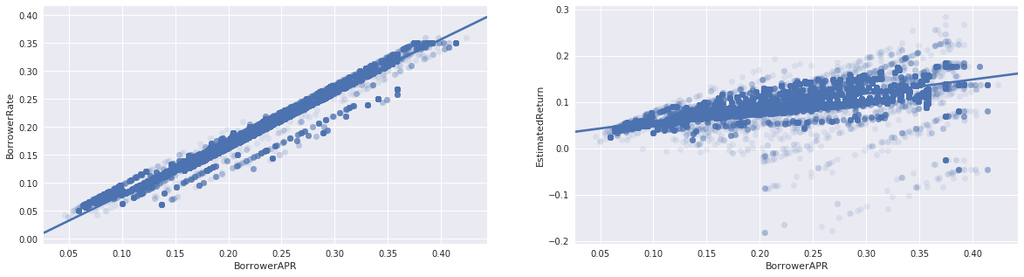

```python
# plot some numerical variables against the APR, this time with full data.
fig, axes = plt.subplots(
    nrows = 1,
    ncols = 2,
    figsize = [20,5]
)

plot_numerical_vars(
    'BorrowerAPR',
    ['BorrowerRate', 'EstimatedReturn']
)
```

Let's move on to looking at how the loan amount and the annual percentage rate (**numerical variables** of interest) correlate with the **categorical variables**.

```python
def boxgrid(x, y, **kwargs):
    default_color = sb.color_palette()[0]
    sb.boxplot(
        x = x,
        y = y,
        color = default_color
    )
```

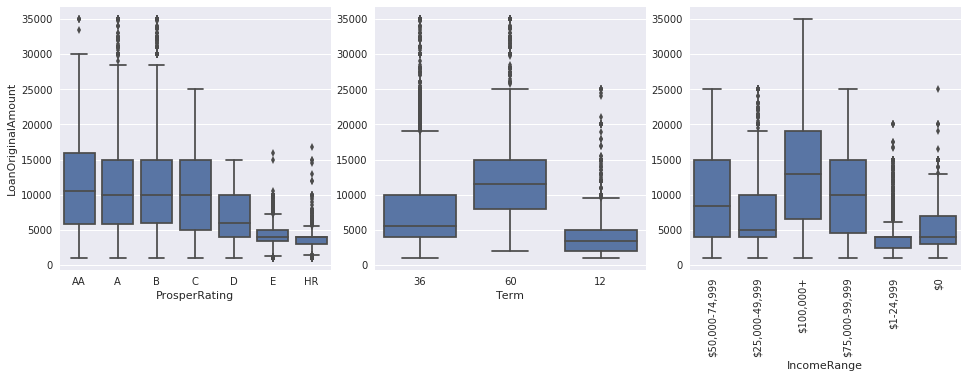

```python
g = sb.PairGrid(
    data = df,
    y_vars = ['LoanOriginalAmount'],
    x_vars = ['ProsperRating', 'Term', 'IncomeRange'],
    size = 4.5,
    aspect = 1
)
g.map(boxgrid)
plt.xticks(rotation = 90);
```

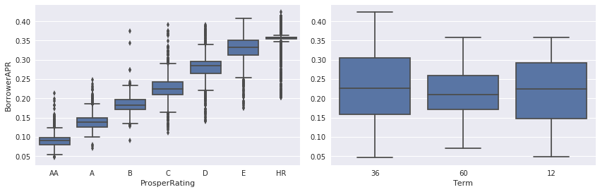

```python
g = sb.PairGrid(
    data = df,
    y_vars = ['BorrowerAPR'],
    x_vars = ['ProsperRating', 'Term'],
    size = 4,
    aspect = 1.5
)
g.map(boxgrid);
```

There is a very strong positive relationship between the Borrower's Annual Percentage Rate (APR) and the Posper rating assigned to the loan. Thus, those loans with a very small annual loss rate ('AA', 'A' or 'B') have a small APR value and those rated as high risk ('D', 'E', 'HR') have a high APR value.

In the second plot, the median has a similar value for the three possible options. There is no linear relationship between the annual percentage rate and the length of the loan.

Now, I will take a look between the categorical variable of interest (LoanStatus) and the other numerical variables.

As seen in the previous section, 89.8% of the loans are still in the process of being repaid or have been completed. Let's see if there is any relationship between the amount of the loan and its status.

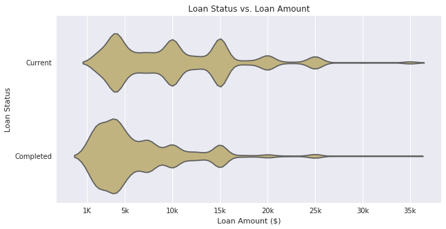

```python
loan_status_df = df[(df.LoanStatus == 'Current') | (df.LoanStatus == 'Completed')]

plt.figure(figsize = (10,5))

sb.violinplot(
    data = loan_status_df,
    y = 'LoanStatus',
    x = 'LoanOriginalAmount',
    inner = None,
    color = sb.color_palette()[4]
)
plt.title('Loan Status vs. Loan Amount')
plt.ylabel('Loan Status')
plt.xlabel('Loan Amount ($)')
plt.xticks(
    [1e3, 5e3, 10e3, 15e3, 20e3, 25e3, 30e3, 35e3],
    ['1K', '5k', '10k', '15k', '20k', '25k', '30k', '35k']
);
```

The area of each plot shows the distribution of the points. It can be seen that loans that have already been completed are concentrated mainly in the areas corresponding to the smaller amounts of money, although the long tail suggests some outliers. Loans in "current" status are more evenly distributed along the x-axis.

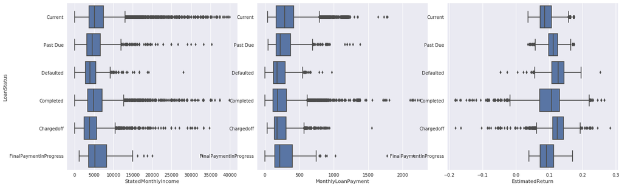

```python
g = sb.PairGrid(
    data = df,
    y_vars = ['LoanStatus'],
    x_vars = ['StatedMonthlyIncome','MonthlyLoanPayment', 'EstimatedReturn'],
    size = 6,
    aspect = 1
)
g.map(boxgrid);
```

No relationships are observed between loan status and the stated monthly income, monthly payment amount or estimated return.

Finally, let's look at relationships between **categorical features.**

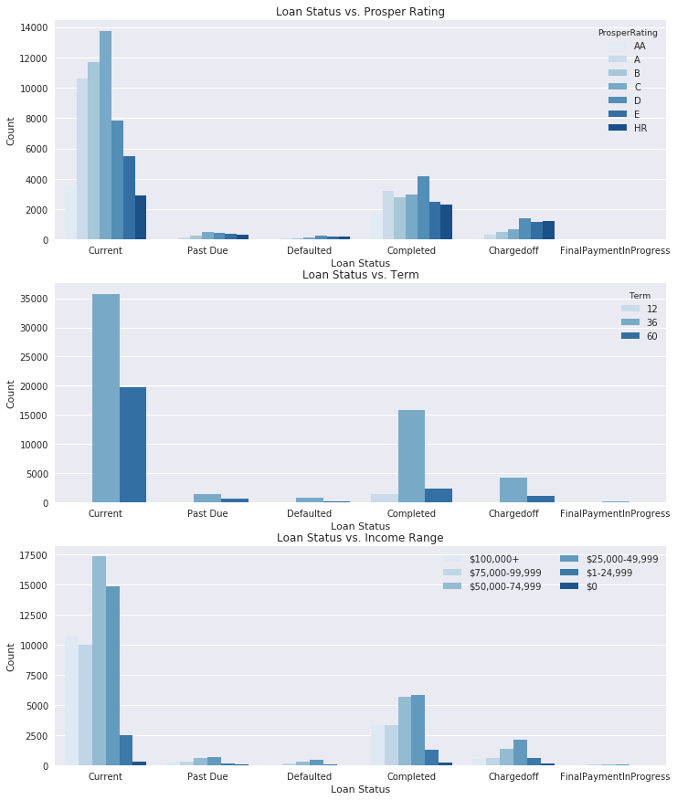

```python
# since there's only three subplots to create, using the full data should be fine
plt.figure(figsize = [12, 15])

# subplot 1: loan status vs. prosper rating
plt.subplot(3, 1, 1)
sb.countplot(
    data = df,
    x = 'LoanStatus',
    hue = 'ProsperRating',
    palette = 'Blues'
)
plt.title('Loan Status vs. Prosper Rating')
plt.ylabel('Count')
plt.xlabel('Loan Status')

# subplot 2: loan status vs. term
ax = plt.subplot(3, 1, 2)
sb.countplot(
    data = df,
    x = 'LoanStatus',
    hue = 'Term',
    hue_order = [12, 36, 60],
    palette = 'Blues'
)
plt.title('Loan Status vs. Term')
plt.ylabel('Count')
plt.xlabel('Loan Status')

# subplot 3: loan status vs. income range
ax = plt.subplot(3, 1, 3)
sb.countplot(
    data = df,
    x = 'LoanStatus',
    hue = 'IncomeRange',
    hue_order = [
        '$100,000+',
        '$75,000-99,999',
        '$50,000-74,999',
        '$25,000-49,999',
        '$1-24,999',
        '$0'
    ],
    palette = 'Blues'
)
# re-arrange legend to remove possible overlapping
ax.legend(loc = 1, ncol = 2)
plt.title('Loan Status vs. Income Range')
plt.ylabel('Count')
plt.xlabel('Loan Status');
```

It appears that, regardless of the status, the loans are characterised by an estimated annual loss rate in the range of 4.00-11.99% ('B', 'C', 'D'), being granted with a repayment term of 36 months. For the rest of the loan status there are no relevant differences.

There is also no significant trend in income range as the vast majority of borrowers are in the \$25,000-74,999 range, as seen in the previous section.

With the preliminary look at bivariate relationships out of the way, I want to dig into some of the relationships more.

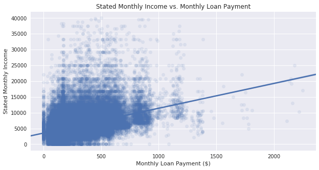

```python
plt.figure(figsize = (10,5))

sb.regplot(
    data = df,
    y = 'StatedMonthlyIncome',
    x = 'MonthlyLoanPayment',
    truncate = False,
    scatter_kws = {'alpha':1/10}
)
plt.title('Stated Monthly Income vs. Monthly Loan Payment')
plt.ylabel('Stated Monthly Income')
plt.xlabel('Monthly Loan Payment ($)');
```

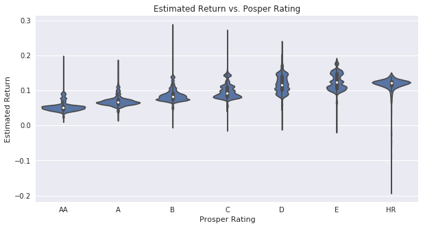

```python
plt.figure(figsize = (10,5))

sb.violinplot(
    data = df,
    x = 'ProsperRating',
    y = 'EstimatedReturn',
    color = sb.color_palette()[0]
)
plt.title('Estimated Return vs. Posper Rating')
plt.ylabel('Estimated Return')
plt.xlabel('Prosper Rating');
```

The estimated return assigned to the loan is also linearly related to the Prosper rating.

### Talk about some of the relationships you observed in this part of the investigation. How did the feature(s) of interest vary with other features in the dataset?

The original loan amount has a positive linear relationship with the monthly payment variable, the borrower's monthly income range and the length of the loan. However, it is negatively correlated with the borrower's annual percentage rate and the borrower's interest rate.

The borrower's annual percentage rate and the borrower's interest rate are two closely related values and, together with the estimated return, are used by Prosper to assign a rating to the loan which helps potential investors to easily consider the risk level of a loan application.

Regarding the status of the loan, the percentage of loans that are currently being paid or have already been completed is very high, with the status of the remaining loans being very insignificant. In general, loans already paid correspond to small amounts of money.

### Did you observe any interesting relationships between the other features (not the main feature(s) of interest)?

Expected relationships were found in the association between the monthly loan payment and the stated monthly income and between the rating assigned by the company and the estimated return for the loan.

## Multivariate Exploration

The main thing I want to explore is how the variables that set the annual interest rate of the loan and the estimated return assigned by the company relate to each other to inform potential investors.

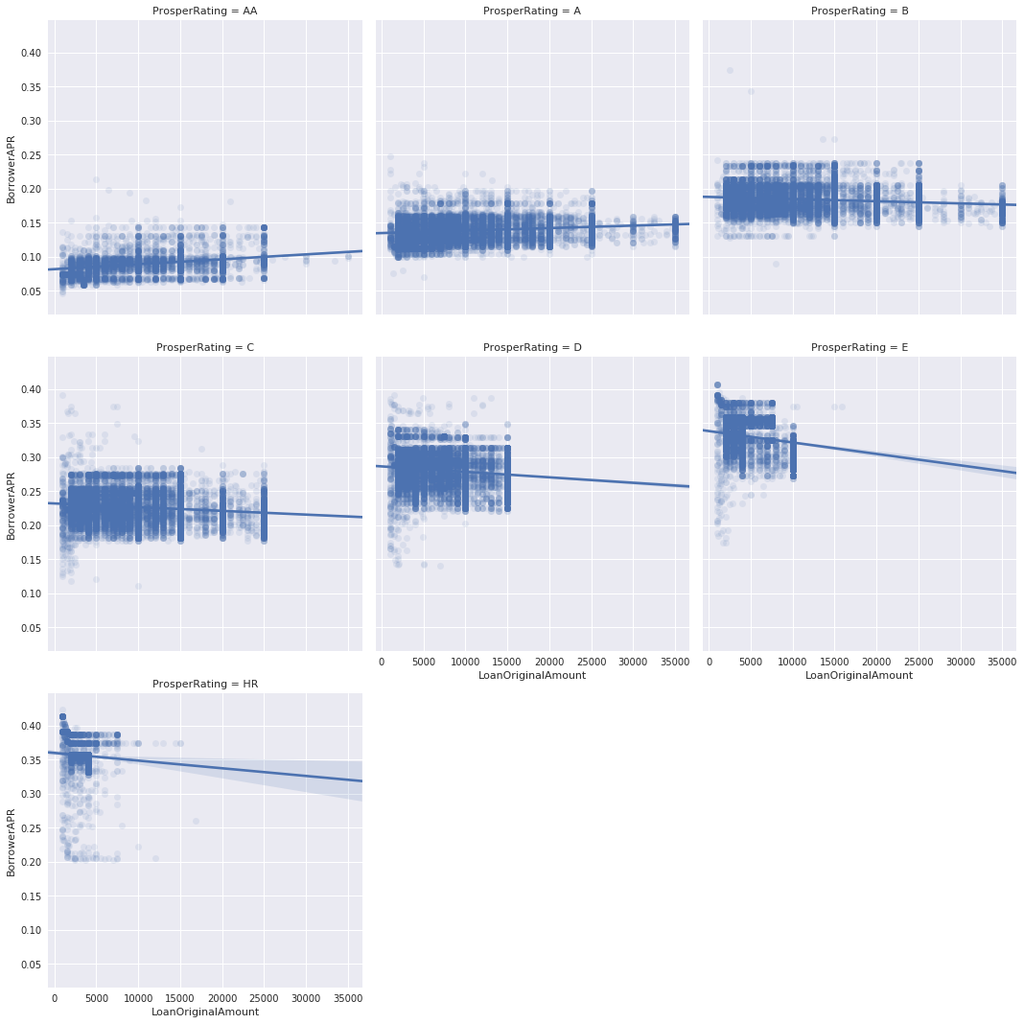

```python
g = sb.FacetGrid(
    data = df,
    col = 'ProsperRating',
    col_wrap = 3,
    size = 5
)
g.map(
    sb.regplot,
    'LoanOriginalAmount',
    'BorrowerAPR',
    truncate = False,
    scatter_kws = {'alpha':1/10}
);
```

In each of the faceted scatterplot it can see the relationship between the borrower's annual percentage rate (APR) and the original loan amount for each of the assigned Prosper ratings. Surprisingly, for loans with a 'AA' and 'A' rating, the APR value increases very slightly as the loan amount increases. For all other ratings, as seen above, there is a negative correlation, as the loan amount increases, the APR decreases.

Finally, let's look at the relationship between the estimated return, the borrower's interest rate and Prosper rating.

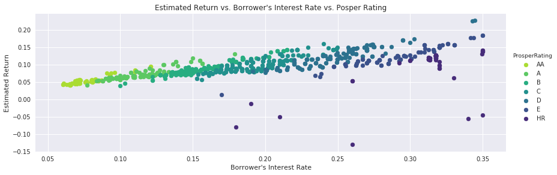

```python
loans_sample = df.sample(n = 1000, replace = False)

g = sb.FacetGrid(
    data = loans_sample,
    hue = 'ProsperRating',
    size = 4,
    aspect = 3,
    palette = 'viridis_r'
)
g.map(
    plt.scatter,
    'BorrowerRate',
    'EstimatedReturn'
)
g.add_legend()
plt.title("Estimated Return vs. Borrower's Interest Rate vs. Posper Rating")
plt.ylabel('Estimated Return')
plt.xlabel("Borrower's Interest Rate");
```

This plot shows a clear pattern between the three variables. The estimated return definitely has a positive linear relationship with the borrower's interest rate and Prosper rating.

### Talk about some of the relationships you observed in this part of the investigation. Were there features that strengthened each other in terms of looking at your feature(s) of interest?

This section has reinforced the relationship between the features that set the monthly payment and the total price the borrower will have to pay to complete the loan repayment. The original loan amount is closely related to the APR value and to the Prosper rating. In addition, unusual behaviour has been discovered for ratings with a very small annual loss rate. These ratings, at the same time, also maintain a positive linear relationship with the estimated loan return.

### Were there any interesting or surprising interactions between features?

Looking back on the faceted scatterplots, the correlation becomes slightly positive when the ratings are 'A' and 'AA'.

## Conclusions

In the course of this research, the relationships between some of the most important parameters when applying for a loan have been explored.

What are the differences between loans depending on how large the original loan amount is ? There are certain features that differentiate loans according to the original loan amount. Generally, as the loan amount increases, so does the length of the loan, i.e. larger loans are granted for 60 months. The borrower's annual percentage rate (APR) and the borrower's interest rate for this loan are inversely proportional to the loan amount. This means that smaller loan amounts will have higher interest rates and vice versa. In turn, these two pieces of information are used to calculate the monthly payment amount, which also increases as the loan amount increases. The borrower's annual income range is positively related to the original loan amount, which means that loans are not granted beyond the borrower's financial means. Finally, the purpose or reason for applying for these loans did not prove to be a differentiating element as a very significant percentage of these loans (76.8%) were granted for debt consolidation, home improvement or business purposes.

For all loans contained in the dataset, 89.8% of the loans granted are in the process of being repaid or have already been completed. The most significant difference was found in the original loan amount, the smallest loans usually having already been repaid. No other factors affecting the status of the loan have been observed.